# Statistical inference with the GSS data

## Setup

### Load packages

```r
library(ggplot2)
library(dplyr)
library(statsr)
```

### Load data

```r
load("gss.Rdata")
```

## Part 1: Data

The data used in this project is taken from GSS that is General Social Survey which gathers information on contemporary American Society to monitor and explain trends and constants in attitudes, behaviors, and attributes. GSS is a socialogical survey that has been collecting the data since 1972 by the National Opinion Research Center. We can only infer any correlation and not causation as no random assignment was used (source: WikiPedia)

Ransom Samples are taken for this Analysis.The Variables used in this analysis are Number of Children (child) and Family income when they were 16 (incom16) Then income variable is a catagorical variable and as 6 categories namely “Far Below Average”, “Below Average”, “Average”, “Above Average”, “Far Above Average”, “Lived in Institution”, “Not Apllicable”. Child is a variable with values 0 to 8. * * *

## Part 2: Research question

This analysis aims to determine any relation between the family income at the age of 16 and the number of children.

## Part 3: Exploratory data analysis

Exploring The Family Income at the age of 16 Variable.

```r
table(gss$incom16)
```

```
##
##    Far Below Average        Below Average              Average
##                 3725                10692                21941
##        Above Average    Far Above Average Lived In Institution
##                 6575                  796                   10
```

```r
round(prop.table(table(gss$incom16)), digits = 2)
```

```
##
##    Far Below Average        Below Average              Average
##                 0.09                 0.24                 0.50
##        Above Average    Far Above Average Lived In Institution
##                 0.15                 0.02                 0.00
```

Exploring the number of children variable.

```r
table(gss$child)
```

```
##
##     0     1     2     3     4     5     6     7     8
## 15493  9077 14058  8855  4654  2144  1097   614   888
```

```r
summary(gss$child)
```

```
##    Min. 1st Qu.  Median    Mean 3rd Qu.    Max.    NA's
##   0.000   0.000   2.000   1.953   3.000   8.000     181
```

Joining the Two Tables to see the data of number of children for each category of house income at the age of 16

```r
table(gss$child, gss$incom16)
```

```
##
##     Far Below Average Below Average Average Above Average
##   0               648          2382    6181          2369
##   1               561          1691    3595           989
##   2               898          2626    5420          1534
##   3               649          1778    3330           872
##   4               376          1007    1743           443
##   5               218           529     758           173
##   6               134           281     360            85
##   7                81           148     213            42
##   8               149           223     286            49
##
##     Far Above Average Lived In Institution
##   0               251                    2
##   1               124                    3
##   2               167                    5
##   3               135                    0
##   4                61                    0
##   5                23                    0
##   6                10                    0
##   7                 9                    0
##   8                16                    0
```

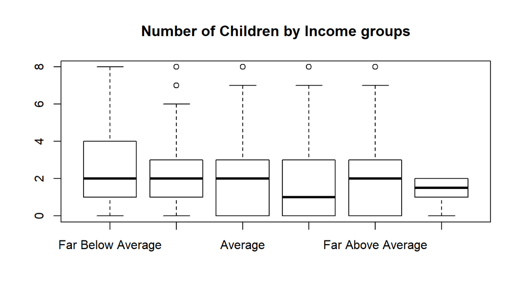

```r
boxplot(gss$child ~ gss$incom16, main = "Number of Children by Income groups")
```

[figure not shown]

```r
ggplot(data=gss,aes(x=gss$child, y=gss$incom16,fill=gss$incom16))+geom_bar(stat="identity")
```

## Part 4: Inference

```r
 chisq.test(gss$child, gss$incom16)
```

```
##
##  Pearson's Chi-squared test
##
## data:  gss$child and gss$incom16
## X-squared = 1005.3, df = 40, p-value < 2.2e-16
```

From the above Chi-Sqaured test to infer our hypothesis is correct, we see that the p-value is close to zero and we can reject our null hypothesis. But, we need to check if there is enough variance in our dataset to finalize our conclusion.

```r
sapply(split(gss$child, gss$incom16), sd, na.rm = TRUE)
```

```
##    Far Below Average        Below Average              Average
##            2.0555286            1.8773883            1.7432149
##        Above Average    Far Above Average Lived In Institution
##            1.6480633            1.8282238            0.8232726
```

When we traverse the data to check the Standard deviation of each category using SApply, we see that amost all the category has Standard Deviation somewhat close to each other, Hence the Variance of the data for Each category of family income at the age of 6 is almost the same, proving that the above chi test is correct and we can reject the null Hypthesis, but, before that we can perform thr ANOVA to find out the variance to confirm our Hypothesis.

```r
anova(lm(gss$child ~ gss$incom16))
```

```
## Analysis of Variance Table
##
## Response: gss$child
##                Df Sum Sq Mean Sq F value    Pr(>F)
## gss$incom16     5   2881  576.21  179.22 < 2.2e-16 ***
## Residuals   43621 140246    3.22
## ---
## Signif. codes:  0 '***' 0.001 '**' 0.01 '*' 0.05 '.' 0.1 ' ' 1
```

As we see that the P value is < 2.2e-16 which is convinvincing enough the data and its means has variance.

```r
TukeyHSD(aov(gss$child ~ gss$incom16), conf.level = 0.95)
```

```
##   Tukey multiple comparisons of means
##     95% family-wise confidence level
##
## Fit: aov(formula = gss$child ~ gss$incom16)
##
## $`gss$incom16`
##                                               diff         lwr        upr
## Below Average-Far Below Average        -0.34804461 -0.44540005 -0.2506892
## Average-Far Below Average              -0.66828747 -0.75896779 -0.5776071
## Above Average-Far Below Average        -0.94488674 -1.04982697 -0.8399465
## Far Above Average-Far Below Average    -0.69688575 -0.89646161 -0.4973099
## Lived In Institution-Far Below Average -1.24738826 -2.86539793  0.3706214
## Average-Below Average                  -0.32024285 -0.38058431 -0.2599014
## Above Average-Below Average            -0.59684212 -0.67703328 -0.5166510
## Far Above Average-Below Average        -0.34884113 -0.53658749 -0.1610948
## Lived In Institution-Below Average     -0.89934365 -2.51593681  0.7172495
## Above Average-Average                  -0.27659927 -0.34853996 -0.2046586
## Far Above Average-Average              -0.02859828 -0.21297164  0.1557751
## Lived In Institution-Average           -0.57910080 -2.19530570  1.0371041
## Far Above Average-Above Average         0.24800099  0.05621187  0.4397901
## Lived In Institution-Above Average     -0.30250153 -1.91956919  1.3145661
## Lived In Institution-Far Above Average -0.55050251 -2.17645636  1.0754513
##                                            p adj
## Below Average-Far Below Average        0.0000000
## Average-Far Below Average              0.0000000
## Above Average-Far Below Average        0.0000000
## Far Above Average-Far Below Average    0.0000000
## Lived In Institution-Far Below Average 0.2390224
## Average-Below Average                  0.0000000
## Above Average-Below Average            0.0000000
## Far Above Average-Below Average        0.0000018
## Lived In Institution-Below Average     0.6082856
## Above Average-Average                  0.0000000
## Far Above Average-Average              0.9978788
## Lived In Institution-Average           0.9110741
## Far Above Average-Above Average        0.0031296
## Lived In Institution-Above Average     0.9948441
## Lived In Institution-Far Above Average 0.9290254
```